# **secr** simulations ARR

Murray Efford

2025-03-29

# Array dimensions ARR

The simulations described here are part of a series documenting the effect of breaching assumptions of spatially explicit capture–recapture models.

A detector array that is too small will likely result in biased estimates. Simulations were provided for searched areas by Efford (2011 Table 3).

These simulations extend the empirical basis for the conclusion.

## Settings

Square grid of 64 binary proximity detectors at spacing $c = 2$.

Also elongated grid 16 x 4.

The same conditions were used for simulation and fitting.

| Parameter | Value(s) |
| --- | --- |
| detectfn | ‘HHN’ |
| D | $12.5 (c/2)^{-2}$ |
| lambda0 | 0.1 |
| sigma | variable |
| noccasions | 10 |
| buffer | $4\sigma$ |
| nx | 64 |

## Package version, date and platform

```r
source('../setup.R')
runsim  <- FALSE
runextra <- FALSE
figures <- TRUE
cache   <- TRUE
nrepl   <- 500
nrepl2  <- 200
metadata(runsim, extra = runextra) # if not run picks up saved metadata.RDS
```

```
## R version 4.3.2 (2023-10-31)
## Platform   x86_64-pc-linux-gnu (64-bit)
## Running    CentOS Linux 7 (Core)
## secr       4.6.7 2024-05-18
## secrdesign 2.9.2 2024-05-18
## Threads    40
## Run        Tue Jun 11 12:46:12 2024
```

## Simulation code

### Define ARR scenarios

```r
grid <- make.grid(nx = 8, ny = 8, spacing = 40, detector = "proximity")
fitarg <- expand.arg(detectfn = c(14,16))
ratio <- seq(0.5,2.5,0.25)
R95 <- max(dist(grid)) / ratio
scen <- make.scenarios(D = 12.5, noccasions = 10, detectfn = 14,
    lambda0 = 0.1, sigma = R95/2/2.45, fitindex = 1:2)
# scale density to avoid variation in # detections due to sigma
# result corresponds to D = 12.5 when sigma = 20 (outside simulated range)
scen$D <- scen$D / (scen$sigma / 20)^2
```

```r
scenarioSummary(scen, grid)
```

```
##    scenario trapsindex noccasions nrepeats       D lambda0   sigma detectfn     En     Er     Em
## 1         1          1         10        1 0.19141     0.1 161.624       14 18.260 177.88 173.59
## 2         2          1         10        1 0.43066     0.1 107.750       14 21.861 174.28 168.42
## 3         3          1         10        1 0.76563     0.1  80.812       14 26.305 169.84 162.08
## 4         4          1         10        1 1.19629     0.1  64.650       14 31.456 164.69 154.84
## 5         5          1         10        1 1.72266     0.1  53.875       14 37.238 158.90 146.85
## 6         6          1         10        1 2.34473     0.1  46.178       14 43.602 152.54 138.21
## 7         7          1         10        1 3.06250     0.1  40.406       14 50.488 145.65 129.02
## 8         8          1         10        1 3.87598     0.1  35.917       14 57.807 138.33 119.45
## 9         9          1         10        1 4.78516     0.1  32.325       14 65.422 130.72 109.66
## 10       10          1         10        1 0.19141     0.1 161.624       14 18.260 177.88 173.59
## 11       11          1         10        1 0.43066     0.1 107.750       14 21.861 174.28 168.42
## 12       12          1         10        1 0.76563     0.1  80.812       14 26.305 169.84 162.08
## 13       13          1         10        1 1.19629     0.1  64.650       14 31.456 164.69 154.84
## 14       14          1         10        1 1.72266     0.1  53.875       14 37.238 158.90 146.85
```

[output cut: 23 more lines]

### Run ARR simulations

```r
ARRsims <- run.scenarios(
    nrepl     = nrepl,
    scenarios = scen,
    trapset   = grid,
    nx        = 64,
    fit       = TRUE,
    fit.args  = fitarg,
    seed      = 12345)
saveRDS(ARRsims, file = 'ARRsims.RDS')
```

### Repeat with elongated grid

```r
grid2 <- make.grid(nx = 16, ny = 4, spacing = 40, detector = "proximity")
fitarg <- expand.arg(detectfn = c(14,16))
ratio <- seq(0.5,2.5,0.25)
R95 <- max(dist(grid2)) / ratio
scen2 <- make.scenarios(D = 12.5, noccasions = 10, detectfn = 14,
    lambda0 = 0.1, sigma = R95/2/2.45, fitindex = 1:2)
# scale density to avoid variation in # detections due to sigma
# result corresponds to D = 12.5 when sigma = 20 (outside simulated range)
scen2$D <- scen2$D / (scen2$sigma / 20)^2
```

```r
ARR2sims <- run.scenarios(
    nrepl     = nrepl2,
    scenarios = scen2,
    trapset   = grid2,
    nx        = 128,         # increase to maintain approximately same spacing
    fit       = TRUE,
    fit.args  = fitarg,
    seed      = 12345)
saveRDS(ARR2sims, file = 'ARR2sims.RDS')
```

## Results

ARRsims completed with 500 replicates on 20 threads in 476.2 minutes.

```r
estD <- estimateSummary(ARRsims)
estD
```

```
##    scenario  true.D nvalid     EST     seEST         RB      seRB     RSE     RMSE   rRMSE   COV
## 1         1 0.19141    500 0.20347 0.0028889  0.0630127 0.0150928 0.32971 0.065650 0.34299 0.950
## 2         2 0.43066    500 0.44277 0.0048213  0.0281140 0.0111950 0.25313 0.108378 0.25165 0.950
## 3         3 0.76563    500 0.76247 0.0071660 -0.0041191 0.0093597 0.21798 0.160108 0.20912 0.956
## 4         4 1.19629    500 1.20077 0.0101543  0.0037419 0.0084882 0.19174 0.226874 0.18965 0.948
## 5         5 1.72266    500 1.71717 0.0133240 -0.0031825 0.0077345 0.17358 0.297685 0.17281 0.946
## 6         6 2.34473    500 2.34140 0.0173764 -0.0014190 0.0074108 0.15897 0.388174 0.16555 0.942
## 7         7 3.06250    500 3.02917 0.0192247 -0.0108828 0.0062774 0.14755 0.430738 0.14065 0.952
## 8         8 3.87598    500 3.88909 0.0231717  0.0033844 0.0059783 0.13642 0.517783 0.13359 0.940
## 9         9 4.78516    500 4.80503 0.0271748  0.0041529 0.0056790 0.12860 0.607363 0.12693 0.950
## 10       10 0.19141    500 0.15758 0.0024751 -0.1767412 0.0129314 0.30802 0.064819 0.33864 0.832
## 11       11 0.43066    500 0.36814 0.0042564 -0.1451759 0.0098833 0.25297 0.113795 0.26423 0.904
## 12       12 0.76563    500 0.67483 0.0065482 -0.1185855 0.0085528 0.21937 0.172162 0.22487 0.914
## 13       13 1.19629    500 1.09712 0.0091548 -0.0828989 0.0076527 0.19477 0.227281 0.18999 0.946
## 14       14 1.72266    500 1.65370 0.0121612 -0.0400287 0.0070595 0.17408 0.280275 0.16270 0.956
## 15       15 2.34473    500 2.27618 0.0156383 -0.0292331 0.0066696 0.16001 0.355995 0.15183 0.958
## 16       16 3.06250    500 2.96262 0.0184264 -0.0326126 0.0060168 0.14872 0.423558 0.13830 0.956
## 17       17 3.87598    500 3.83498 0.0228052 -0.0105777 0.0058837 0.13738 0.511078 0.13186 0.956
## 18       18 4.78516    500 4.82851 0.0272686  0.0090595 0.0056986 0.12843 0.610675 0.12762 0.952
```

Note: rRMSE is the root-mean-square error divided by the true density.

$\mbox{rRMSE}(\hat D) = \frac{1}{D} \sqrt {\frac{1}{N} \sum_{i=1}^N {(D - \hat D_i)^2}}$

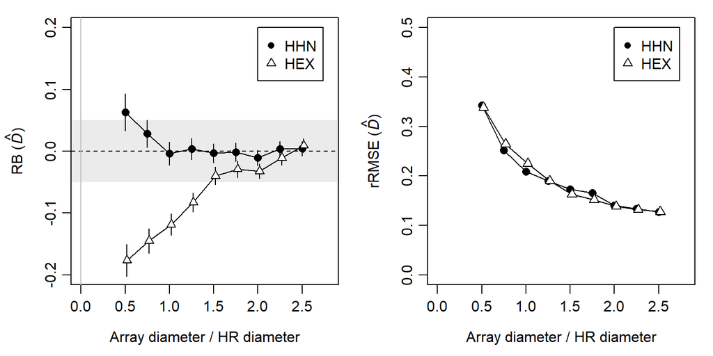

Effect of array size on relative bias (RB) and relative root-mean-square error (rRMSE) of density estimates

## Supplementary results 2025-03-28

ARR2sims completed with 200 replicates on 20 threads in 643.2 minutes.

```r
estD <- estimateSummary(ARR2sims)
estD
```

```
##    scenario   true.D nvalid      EST     seEST          RB     seRB     RSE     RMSE   rRMSE   COV
## 1         1 0.080162    200 0.087748 0.0021034  0.09464224 0.026240 0.35388 0.030627 0.38206 0.945
## 2         2 0.180364    200 0.185332 0.0033274  0.02754810 0.018448 0.28419 0.047201 0.26170 0.960
## 3         3 0.320646    200 0.320906 0.0051464  0.00080943 0.016050 0.24609 0.072600 0.22642 0.960
## 4         4 0.501010    200 0.504203 0.0080600  0.00637224 0.016088 0.22306 0.113745 0.22703 0.940
## 5         5 0.721454    200 0.737149 0.0104673  0.02175380 0.014509 0.20273 0.148491 0.20582 0.940
## 6         6 0.981980    200 0.980072 0.0117769 -0.00194235 0.011993 0.19146 0.166144 0.16919 0.980
## 7         7 1.282585    200 1.308819 0.0158249  0.02045387 0.012338 0.17801 0.224774 0.17525 0.935
## 8         8 1.623272    200 1.610503 0.0191102 -0.00786662 0.011773 0.17107 0.269885 0.16626 0.935
## 9         9 2.004040    200 2.020352 0.0224792  0.00813941 0.011217 0.16009 0.317528 0.15844 0.935
## 10       10 0.080162    200 0.062489 0.0014554 -0.22046342 0.018156 0.32302 0.027090 0.33794 0.810
## 11       11 0.180364    200 0.146205 0.0030613 -0.18938815 0.016973 0.27512 0.055061 0.30528 0.850
## 12       12 0.320646    200 0.268181 0.0047558 -0.16362379 0.014832 0.24908 0.085168 0.26561 0.910
## 13       13 0.501010    200 0.433835 0.0068702 -0.13407926 0.013713 0.22508 0.117921 0.23537 0.905
## 14       14 0.721454    200 0.649329 0.0092197 -0.09997256 0.012779 0.20806 0.148720 0.20614 0.930
## 15       15 0.981980    200 0.884335 0.0121665 -0.09943595 0.012390 0.19530 0.197462 0.20109 0.935
## 16       16 1.282585    200 1.187691 0.0155286 -0.07398720 0.012107 0.18299 0.238729 0.18613 0.950
## 17       17 1.623272    200 1.541049 0.0167689 -0.05065269 0.010330 0.17095 0.250437 0.15428 0.970
## 18       18 2.004040    200 1.943186 0.0220050 -0.03036539 0.010980 0.16154 0.316327 0.15784 0.925
```

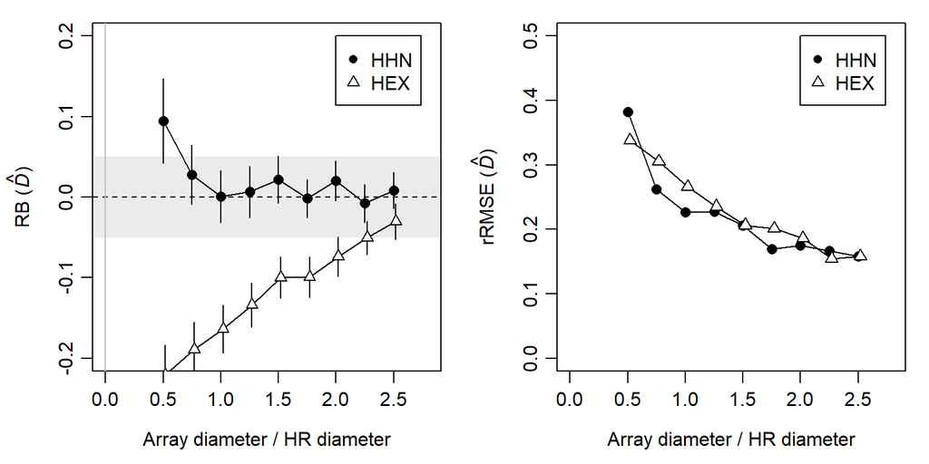

Effect of array size on relative bias (RB) and relative root-mean-square error (rRMSE) of density estimates. Elongated grid.

## Compare Efford 2011 Table 3

Efford (2011 Ecology 92: 2202–2207) simulated area-search data with a half-normal detection function. The searched area varied from $1 \sigma^2$ to $64 \sigma^2$. We plot the results as a function of area-diameter divided by 95% BVN home range as with the preceding simulations. Bias results when the linear diagonal of the searched area is less than about 75% of the 95% home-range diameter. Given the arbitrariness of both measures (area dimension, home range size) we suggest the simple rule: the grid or searched area should be at least the size of the home range.

```r
searcharea <- c(1,2,4,8,16,32,64)
diag <- sqrt(2) * sqrt(searcharea)
HR95 <- 2 * 2.45 * 1
diag/HR95
```

```
## [1] 0.28862 0.40816 0.57723 0.81633 1.15446 1.63265 2.30892
```

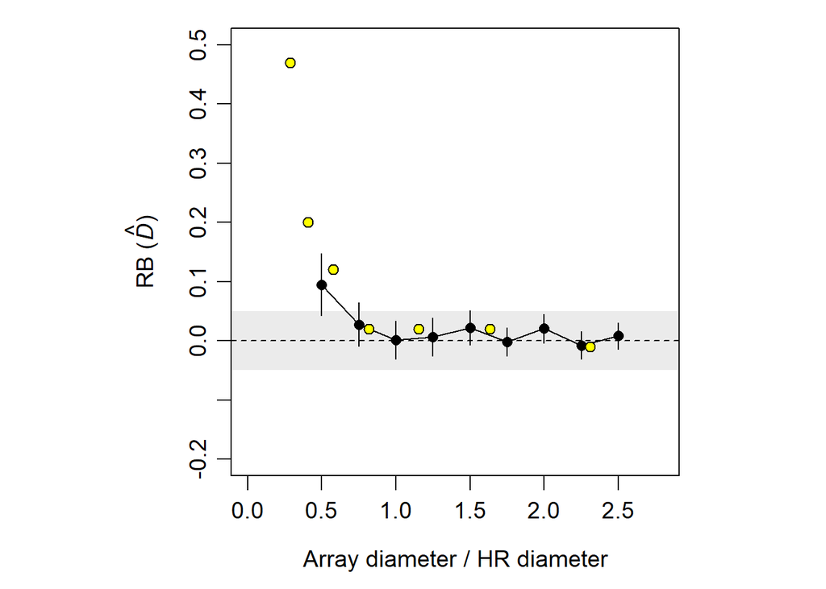

```r
RB <- c(0.47,0.20,0.12,0.02, 0.02, 0.02,-0.01)

par(mfrow=c(1,1), mar=c(4,4,1,1), mgp=c(2.4,0.7,0), bty = 'o', cex = 1.2, pty='s')

plot(0,0,type='n', xlim=c(0,2.8), ylim=c(-0.2, 0.5),
     xlab = 'Array diameter / HR diameter',
     ylab = expression(paste('RB (', hat(italic(D)), ')') ) )
shade(0.05)
abline(h=0, lty=2)
addRB(x, estD[1:9,], type='o', pch=16, cex=1)
points(diag/HR95, RB, pch=21, bg='yellow')
```